# VV4

## B

### a)

gagnasafn: $(x_1,y_1),...,(x_n,y_n)$  
formúla: $y = ax+b$  
$S(a,b)=\sum_{i=1}^n(ax_i+b-y_i)^2$

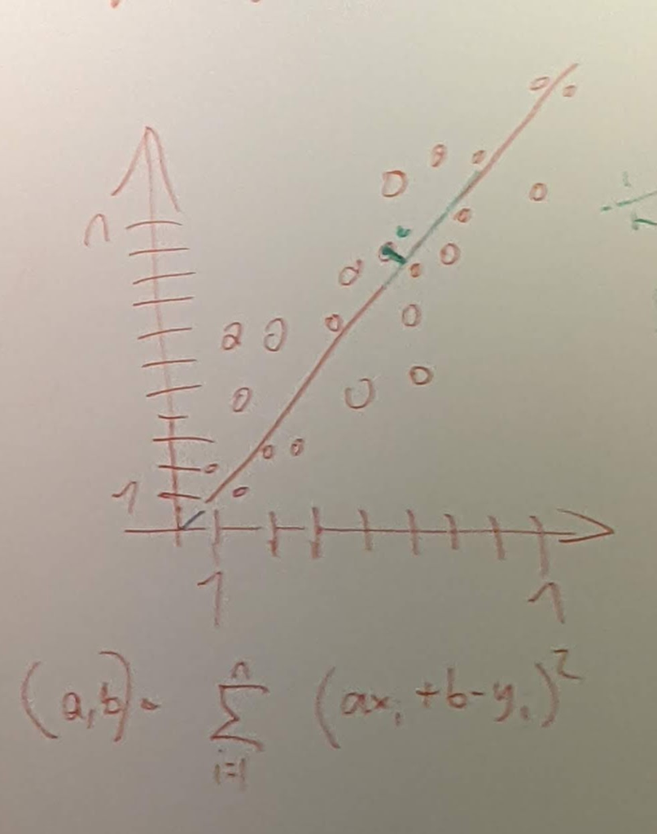

```python
# bara til þess að setja inn mynd
# ehv fucky með export í markdown
from IPython.display import Image
Image(filename='./imgs/bb.jpg')
```

### b)

jafna bestu parabólu gagnasafnsins:  
$S(a,b,c) = \sum_{i=1}^n(ax_i^2+bx_i+c-y_i)^2$

## C

### a)

**BYRJUM ÞETTA** $D_x(x^2+y)^6+e^{y-x}$  
$\frac{\delta}{\delta x}(e^{-x+y})+\frac{\delta}{\delta x}(x^2+y)^6$

**KEÐJUREGLAN**  
$\frac{\delta}{\delta x}(x^2+y)^6+(e^{-x+y}(\frac{\delta}{\delta x}(-x+y))$

**SKIPTA SAMLAGANINGU NÐUR Í BÚTA**  
$\frac{\delta}{\delta x}(x^2+y)^6+(-(\frac{\delta}{\delta x}(x))+\frac{\delta}{\delta x}(y))$  
$\frac{\delta}{\delta x}(x^2+y)^6+(-(1)+\frac{\delta}{\delta x}(y))$  
$\frac{\delta}{\delta x}(x^2+y)^6+(-(1)+0)$  
$-e^{-x+y}+\frac{\delta}{\delta x}(x^2+y)^6$

**OKOK KEÐJUREGLA AFTUR**  
$-e^{-x+y}+(6(x^2+y)^5(\frac{\delta}{\delta x}(x^2+y))$

**SKIPTA NIÐUR**  
$-e^{-x+y}+(6(x^2+y)^5(\frac{\delta}{\delta x}(x^2)+\frac{\delta}{\delta x}(y))$  
$-e^{-x+y}+(6(x^2+y)^5(2x+\frac{\delta}{\delta x}(y))$  
$-e^{-x+y}+(6(x^2+y)^5(2x+0)$

### b)

finnum fyrst $f_x$ og $f_y$  
$f_x: 3x^2+y$  
$f_y: -3y^2+x$

þá er ég með $\nabla f(x,y) = (\binom{3x^2+y}{-3y^2+x})$

## D

### a)

$a=(1,2,3)$, $b=(4,2,0)$, $c=(1,0,1)$

$c_1\begin{pmatrix}1\\2\\3\end{pmatrix}+c_2\begin{pmatrix}4\\2\\0\end{pmatrix}+c_3\begin{pmatrix}1\\0\\1\end{pmatrix}$

1. $c_1+4c_2+c_3=0$
2. $2c_1+2c_2=0$
3. $3c_1+c_3=0$
1. hér eru $c_1$ og $c_3$ andstæður og $c_2$ hlýtur þá að vera 0
2. þar sem $c_2$ er 0 þá getur $c_1$ ekki verið neitt nema 0
3. $c_1$ er 0 þannig $c_3$ verður að vera 0

öll c-in eru 0 þannig vigrarnir eru línulega óháðir

### b)

```python
import numpy as np
import numpy.linalg as la
from math import acos, degrees

a = np.array([1,2,3])
b = np.array([4,2,0])
theta = degrees(acos(a@b/(la.norm(a)*la.norm(b))))
print(theta)
```

```
61.43917478218875
```

hornið á milli vigranna a og b er 61.44 gráður

### c)

$a=(1,2,3)$, $b=(4,2,0)$, $d=(x_1,x_2,x_3)$

$c_1\begin{pmatrix}1\\2\\3\end{pmatrix}+c_2\begin{pmatrix}4\\2\\0\end{pmatrix}+c_3\begin{pmatrix}x_1\\ x_2\\ x_3\end{pmatrix}$

1. $c_1+4c_2+x_1c_3=0$
2. $2c_1+2c_2+x_2c_3=0$
3. $3c_1+x_3c_3=0$
1. byrjum á að láta $x_1$ vera $-4$, þá vitum við að $c_2$ og $c_3$ eru andstæður og $c_1=0$
2. nú þar sem $c_1=0$ þá þarft $x_2$ að vera andstæðan við $2$, þ.e. $-2$
3. núna þarf $0+1*x_3=0$ og þá getur $x_3$ bara verið $0$

þá endum við með vigurinn $d=(-4,-2,0)$

### d)

ef hlutur kostar y og aðilar sem leggja í púkk eru x þá myndu jöfnunar hljóða svona:  
$8x-y=3$  
$7x-y=-4$

fylki jöfnunnar væri $\begin{pmatrix}8&-1\\7&-1 \end{pmatrix}$ og lausnarfylkið væri $\begin{pmatrix}3\\-4\end{pmatrix}$

leysti dæmið með numpy fyrir neðan, bara til gamans

```python
import numpy as np
import numpy.linalg as la

A = np.array([[-1,8],[-1,7]])
b = np .array([3,-4])
sol = la.solve(A,b)
print(f'Gripurinn kostar {int(sol[0])} og það eru {int(sol[1])} kaupendur')
```

```
Gripurinn kostar 53 og það eru 7 kaupendur
```

## E

### a)

```python
import numpy as np
import numpy.linalg as la

upph = np.array([1000,600,400])
leslie = np.array([
    [0.2,0.6,0.8],
    [0.8,0.0,0.0],
    [0.0,0.5,0.0]
])
```

### b)

```python
sea = sum(la.matrix_power(leslie,1)@upph) # stofn eftir ár
print(sea)
```

```
1980.0
```

### c)

#### test nr. 1

fyrsta hugmyndin mín var að brute forcea þetta með while-lykkju, á meðan stofninn er stærri en 100, halda áfram. Lykkjan var ennþá að ganga eftir mínútu svo sú lausn gekk ekki upp.

```python
j = 1
while(sum(la.matrix_power(leslie,j)@upph) > 100): j=+1
```

#### test nr.2

önnur hugmyndin var byggð á útkomuni úr test nr. 1. Svo virðist vera sem stofninn minnki ekki niður fyrir 100 í býsna langann tíma afh er það?

```python
years = [sum(la.matrix_power(leslie,i)@upph) for i in range(1,1000,100)]
print(years)
```

```
[1980.0, 1992.452830188685, 1992.4528301886908, 1992.4528301886962, 1992.4528301887021, 1992.4528301887076, 1992.4528301887133, 1992.452830188719, 1992.4528301887246, 1992.4528301887303]
```

Eins og sést, eftir fyrstu 100 árin er stofninn búinn að ná jafnvægi, ~1992.45 þá má með fullri vissu segja að stofninn mun ekki deyja út, bara til gamans þá plotta ég fyrstu 100 árin

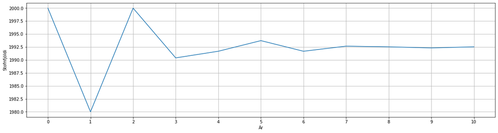

```python
import matplotlib.pyplot as plt

stofn = [sum(la.matrix_power(leslie,i)@upph) for i in range (11)]
years = [j for j in range(11)]

plt.figure(figsize=(20,5))
plt.plot(years,stofn)
plt.xticks(years)
plt.grid(True)
plt.xlabel('Ár')
plt.ylabel('Stofnfjöldi')
plt.show()
```

upprunalega var grafið upp í 100 ár en fjöldinn var orðinn stabíll eftir 10 þannig ég stytti skalann til að gera lesanlegra